# INFLATION ANALYSIS IN THE US ECONOMY

# Time Series Analsis and Forecasting for the Apparel Sector

```r
# Filter data for Electricity sector
apparel_data <- group1_long %>%
  filter(TITLE == "Apparel") %>%
  select(YEAR, Value)
```

```r
# Convert the Apparel sector data to a time series
apparel_ts <- ts(apparel_data$Value, start = c(2014, 1), frequency = 12) # Monthly frequency
```

```r
# Fit an ARIMA model to the Apparel data
apparel_arima <- auto.arima(apparel_ts)
summary(apparel_arima)
```

```
## Series: apparel_ts
## ARIMA(1,0,3)(2,1,1)[12]
##
## Coefficients:
##          ar1     ma1      ma2      ma3     sar1    sar2     sma1
##       0.3832  0.3789  -0.5383  -0.5542  -0.0656  0.5361  -0.3262
## s.e.  0.1427  0.1411   0.0876   0.0650   0.1416  0.0841   0.1713
##
## sigma^2 = 0.0199:  log likelihood = 124.28
## AIC=-232.56   AICc=-231.9   BIC=-205.12
##
## Training set error measures:
##                       ME     RMSE        MAE         MPE       MAPE      MASE
## Training set 0.006845801 0.135362 0.08676617 0.006997594 0.08688664 0.5915876
##                  ACF1
## Training set 0.014361
```

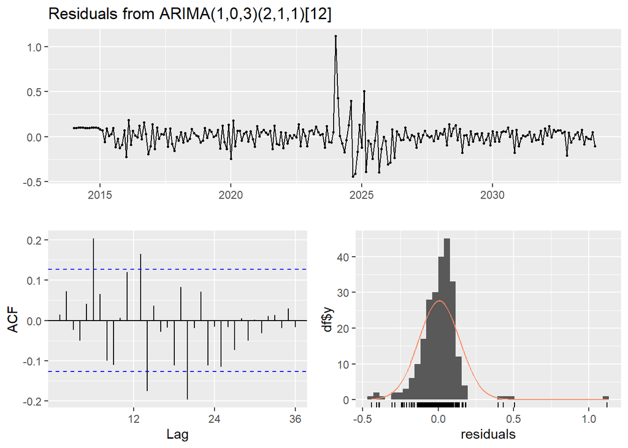

```
##
##  Ljung-Box test
##
## data:  Residuals from ARIMA(1,0,3)(2,1,1)[12]
## Q* = 58.91, df = 17, p-value = 1.589e-06
##
## Model df: 7.   Total lags used: 24
```

```r
# Perform residual diagnostics
checkresiduals(apparel_arima)
```

# Ljung-Box Test for Apparel

- Test Statistic, Q∗=58.91: This is the value of the Ljung-Box test statistic.
- Degrees of Freedom (df) = 17: This is calculated based on the number of lags minus the number of estimated parameters in the model.
- p-value = $1.589 \times 10^{-6}$ : The p-value is way below the standard significance level of 0.05

Conclusion:

Since $p = 1.589 \times 10^{-6}$ is much smaller than the standard significance level ($\alpha = 0.05$), we reject the null hypothesis of the Ljung-Box test.  
This suggests that there is significant autocorrelation remaining in the residuals.

Model Adequacy:

The residuals are not white noise, indicating that the ARIMA(1,0,3)(2,1,1)[12] model does not fully capture the underlying patterns in the data. Further adjustments to the model’s parameters are required, potentially revisiting the AR, MA, or seasonal components to improve fit.